# STAT 360: Computational Statistics and Data Analysis

## PS 2.1 - Marcus Haldane

### Load Relevant R Libraries

```r
library(rmarkdown); library(knitr); library(moments);
library(scatterplot3d); library(corrplot); library(pso)
library(psych); library(GPArotation); library(lavaan)
```

### Exercise 2.01 - Multidimensional Poverty Measure (continued)

#### Part (a)

```r
# Insert code or written answer here
southAmerica <- matrix(c(0.3, 0.0, 0.4, 1.5,
                         7.4, 4.9, 16.3, 13.2,
                         1.7, 0.2, 34.2, 16.0,
                         0.1, 0.3, 0.6, 4.0,
                         2.4, 1.3, 8.2, 5.1,
                         4.3, 1.4, 3.6, 3.9,
                         2.1, 0.3, 9.0, 6.3,
                         6.2, 4.1, 12.1, 5.4,
                         0.5, 0.1, 1.0, 2.0), nrow = 9, ncol = 4, byrow = T,
                       dimnames = list(c("Argentina", "Bolivia", "Brazil", "Chile", "Colombia", "Ecuador", "Paraguay", "Peru", "Uruguay"), c("Water", "Electricity", "Sanitation", "Education")))
southAmerica
```

```
##           Water Electricity Sanitation Education
## Argentina   0.3         0.0        0.4       1.5
## Bolivia     7.4         4.9       16.3      13.2
## Brazil      1.7         0.2       34.2      16.0
## Chile       0.1         0.3        0.6       4.0
## Colombia    2.4         1.3        8.2       5.1
## Ecuador     4.3         1.4        3.6       3.9
## Paraguay    2.1         0.3        9.0       6.3
## Peru        6.2         4.1       12.1       5.4
## Uruguay     0.5         0.1        1.0       2.0
```

#### Part (b)

```r
# Insert code or written answer here
southAmericaCorrelationMatrix <- cor(southAmerica)
southAmericaCorrelationMatrix
```

```
##                 Water Electricity Sanitation Education
## Water       1.0000000   0.9500686  0.3126965 0.4112596
## Electricity 0.9500686   1.0000000  0.2229108 0.3434126
## Sanitation  0.3126965   0.2229108  1.0000000 0.9350945
## Education   0.4112596   0.3434126  0.9350945 1.0000000
```

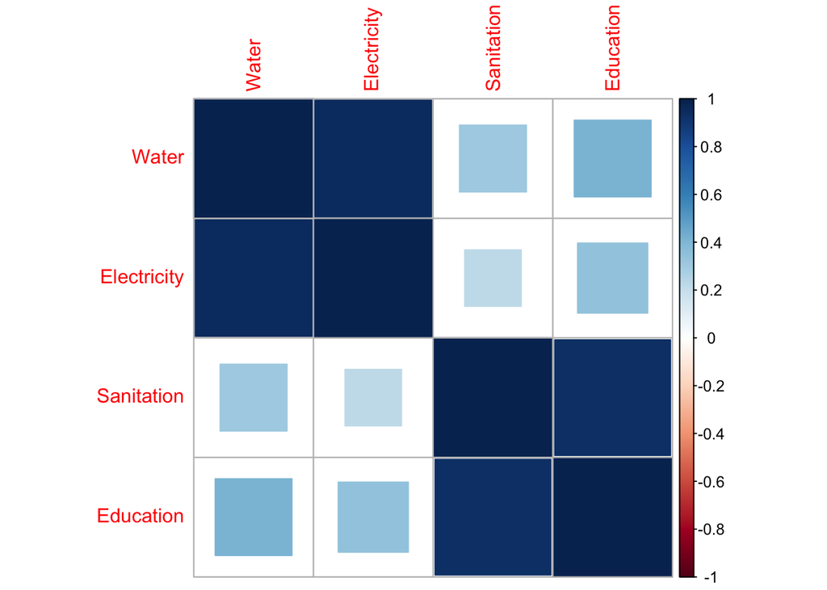

```r
corrplot(southAmericaCorrelationMatrix, method = "square")
```

#### Part (c)

```r
# Insert code or written answer here
eigen(southAmericaCorrelationMatrix)$values
```

```
## [1] 2.59136094 1.30474169 0.06277743 0.04111993
```

#### Part (d)

```r
# Insert code or written answer here
eigen(southAmericaCorrelationMatrix)$values>1
```

```
## [1]  TRUE  TRUE FALSE FALSE
```

```r
eigen(southAmericaCorrelationMatrix)$values>0.7
```

```
## [1]  TRUE  TRUE FALSE FALSE
```

```r
# Written answer directly below
```

The Kaiser’s and Jolliffe’s criteria do not support the World Bank Group’s assertion that access to Water, Electricity, Sanitation, and Education are all aspects or dimensions of a single multidimensional measure of poverty. This is because not all of the eigen values are above the 1.0 and 0.7 levels used as Kaiser and Jolliffe criteria respectively. The third and fourth eigen values are below both thresholds.

### Exercise 2.02 - New Enterprises in South Africa

#### Part (a)

```r
# Insert code or written answer here
obstacleEigenValues = c(20.225, 8.432, 2.356, 2.156, 1.835, 0.895, 0.779, 0.701, 0.653, 0.601, 0.552,0.492,0.452,0.401,0.369,0.301,0.215,0.198,0.182,0.173, 0.167, 0.161, 0.157, 0.152, 0.107, 0.101, 0.040, 0.037, 0.034)
```

#### Part (b)

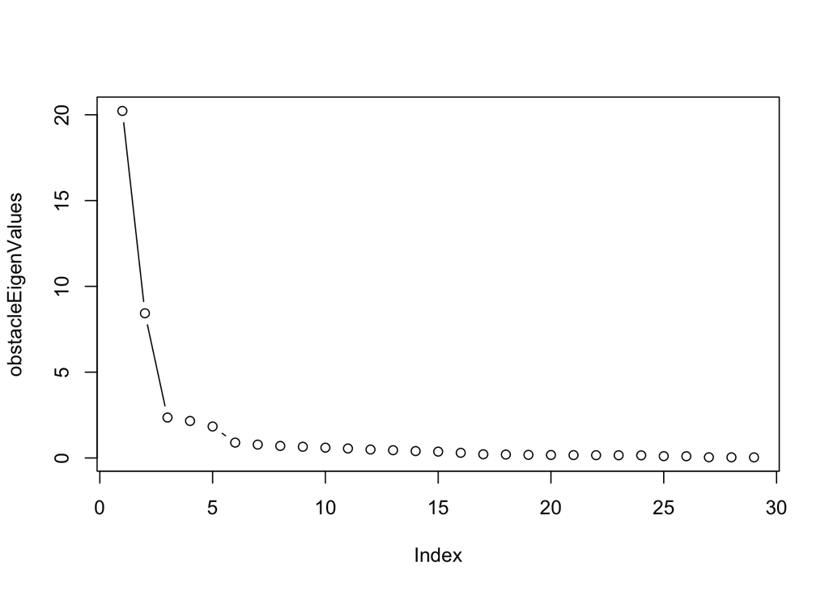

```r
# Insert code or written answer here
plot(obstacleEigenValues, type = "b")
```

#### Part (c)

```r
# Written answer directly below
```

The intrinsic dimensionality found by using the inflection point criterion or scree test would be 2, as the the inflection point occurs at the third eigenvalue.

#### Part (d)

```r
# Insert code or written answer here
length(which(obstacleEigenValues>1))
```

```
## [1] 5
```

```r
#obstacleEigenValues>1
```

#### Part (e)

```r
# Insert code or written answer here
length(which(obstacleEigenValues>0.7))
```

```
## [1] 8
```

```r
#obstacleEigenValues>0.7
```

#### Part (f)

```r
# Written answer directly below
```

The intrinsic dimensionality found by using the inflection point criterion [Part c], Kaiser’s criterion [Part d], and Jolliffe’s criterion [Part e] are all different. The intrinsic dimensionality of Part c is the smallest, since the graph generated in Part B seems to show the eigen values leveling off once the third eigen value is reached. The intrinsic dimensionality of Part e is the largest, since the threshold of 0.7 used as Jolliffe’s criterion is less than the threshold used as Kaiser’s criterion, and the shape and y axis scale of the scree plot from Part b is influenced significantly by the 2 largest eigen values, somewhat hiding the reality that there are 8 eigen values which are greater than 0.7 in the vector.

### Exercise 2.03 - Stock Portfolios (continued)

#### Part (a)

```r
# Insert code or written answer here
stockInfo <- matrix(c(3805, 4980, 42330, 468665, 0.354,
                      4980, 8239, 64715, 700917, 1.401,
                      42330, 64715, 559182, 6294123, 14.990,
                      468665, 700917, 6294123, 80834339, 249.131,
                      0.354, 1.401, 14.990, 249.131, 0.005), nrow = 5, ncol = 5, byrow = T,
                      dimnames = list(c("SOL","BNB","ETH","BTC","DOGE"), c("SOL","BNB","ETH","BTC","DOGE")))
stockInfo
```

```
##             SOL        BNB        ETH          BTC    DOGE
## SOL    3805.000   4980.000   42330.00   468665.000   0.354
## BNB    4980.000   8239.000   64715.00   700917.000   1.401
## ETH   42330.000  64715.000  559182.00  6294123.000  14.990
## BTC  468665.000 700917.000 6294123.00 80834339.000 249.131
## DOGE      0.354      1.401      14.99      249.131   0.005
```

#### Part (b)

```r
# Insert code or written answer here
stockCor <- solve(sqrt(diag(diag(stockInfo)))) %*% stockInfo %*% t(solve(sqrt(diag(diag(stockInfo)))))
stockCor
```

```
##            [,1]      [,2]      [,3]      [,4]       [,5]
## [1,] 1.00000000 0.8894361 0.9176865 0.8450594 0.08115979
## [2,] 0.88943612 1.0000000 0.9534350 0.8588778 0.21828097
## [3,] 0.91768651 0.9534350 1.0000000 0.9361829 0.28349150
## [4,] 0.84505942 0.8588778 0.9361829 1.0000000 0.39187253
## [5,] 0.08115979 0.2182810 0.2834915 0.3918725 1.00000000
```

#### Part (c)

[figure not shown]

```r
# Insert code or written answer here
corrplot(stockCor, method = "color", order = "hclust")
```

#### Part (d)

```r
# Written answer directly below
```

#### Part (e)

```r
# Insert code or written answer here
eigen(southAmericaCorrelationMatrix)$values
```

```
## [1] 2.59136094 1.30474169 0.06277743 0.04111993
```

```r
eigen(southAmericaCorrelationMatrix)$vector
```

```
##            [,1]       [,2]       [,3]       [,4]
## [1,] -0.5182781  0.4627647 -0.3872732  0.6060166
## [2,] -0.4876833  0.5266355  0.2949767 -0.6307209
## [3,] -0.4745501 -0.5462982 -0.5866574 -0.3635843
## [4,] -0.5180300 -0.4583253  0.6471795  0.3205333
```

#### Part (f)

```r
# Written answer directly below
```